# Modelo Polinomial

Rodrigo Velez

30/07/2020

## Aspectos Iniciales

- La escritura se hace sin tildes para evitar problemas a la hora correr el codigo.
- Existe una forma de arreglar este problema, pero puede llegar a ser engorrosa.
- Al momento de abrir un nuevo archivo y elegir Rmarkdown, se deberian instalar automaticamente los paquetes necesarios.

## Borrar Enviroment

Por costumbre y como practica de programacion, se sugiere siempre a borrar al “Enviorment”, el cual es el espacio donde se almacenan los datos a importar asi como todos los objetos creados en el codigo.

```r
rm(list=ls())
```

# 1. Base de datos - Variable

*Nota: En esta seccion tenga en cuenta que se debe describir como minimo: Nombre de la Variable, Fuente de informacion, Unidades, Periodo de analisis, Frecuencia o Periodicidad*

La variable a utilizar es la Tasa de Desempleo Nacional (sin desestacionalizar) de Colombia, calculada y publicada por el Departamento Administrativo Nacional de Estadisticas (DANE). La variable esta en porcentaje, para un periodo desde enero de 2001 hasta mayo de 2020 (233 observaciones) con frecuencia mensual.

## 1.1. Importar Base

*Nota 1: Es posible importar bases de datos en diferentes formatos, en este caso se utiliza el formato .xlsx de excel. Es necesario instalar la libreria readxl*

```r
library(readxl)
desempleo <- read_excel("C:/Users/Rodro/Documents/R/Econometria-Financiera/BD_TD.xlsx")
```

*Nota 2: La direccion de archivo se debe poner con / en vez de backslash, y se finaliza con el nombre del archivo*

## 1.2. Definicion de variables

*Nota 1: Para garantizar que las funciones y librerias a usar funcionen adecuadamente se debe definir las variable a trabajar como serie de tiempo y la fecha en formato de fecha de R*

```r
td = desempleo$TD
td = ts(td, start = c(2001,1), end = c(2020,5), frequency = 12)
Fecha  = as.Date(desempleo$Fecha, format="%Y-%m")
```

*Nota 2: Existen mil formas de definir las variables, utilizando diferentes paquetes. El codigo anterior es solo una de ellas*

## 1.2. Analisis grafico

*Nota 1: Se sugiere siempre graficar la serie e identificar sus componentes y/o comportamiento que llamen la atencion y contribuyan a la modelacion*

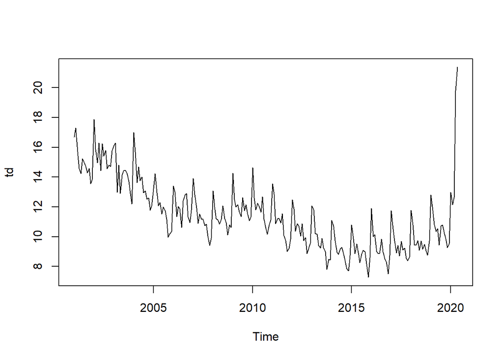

```r
plot(td,type="l") # type="l" significa grafico de linea
```

El codigo anterior crea un grafico bastante sencillo que para un analisis rapido puede ser util. Sin embargo, para propositos de una presentacion se puede hacer algo mas presentable.

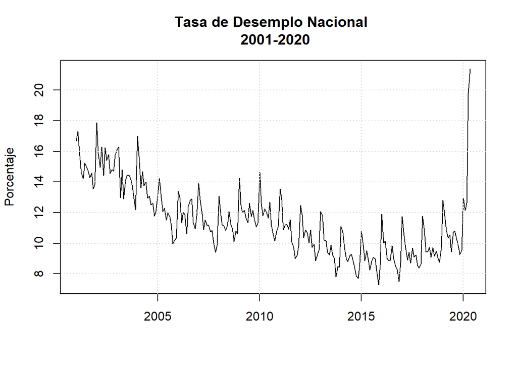

```r
plot(td,type="l", ylab='Porcentaje', xlab='')
title(main = "Tasa de Desemplo Nacional \n 2001-2020") # \n genera una segunda linea en el titulo
grid()                                                 # agrega lineas secundarias
```

*Nota 2: De nuevo existen muchas formas de graficar en R, esta es solo una pequeña muestra sobre como mejorar los graficos. La libreria mas recomendanda para graficar es ggplot2.*

¿Que elementos, componentes o hechos relevantes puede identificar?

# 2. Estimacion

## 2.1. Creacion de variables

Una vez identificado un candidato de polinomio de grado 6 mas 3 dummies para enero, octubre y noviembre. Es decir, es necesario crear dichas variables $t$ y sus transformaciones $t^p$ con $p=1,2,3,...$ mas la dummies que ayudan a incorporar estacionalidad, cambios estructurales o comportamiento atipicos. Para ello se requiere ejecutar las siguientes lineas:

*Nota: Este es un proceso iterativo, el grado del polinomio y las dummies correspondientes son producto de realizar varias estimaciones hasta encontrar el “mejor” modelo*

```r
# Crear la variable "t"

N  = length(td)
t  = seq(1,N)
t2 = t^2
t3 = t^3
t4 = t^4
t5 = t^5
t6 = t^6

# Crear las dummies

dene = as.numeric(months(Fecha) == "January")   # estacionalidad
doct = as.numeric(months(Fecha) == "October")   # estacionalidad
dnov = as.numeric(months(Fecha) == "November")  # estacionalidad
d20  = as.numeric(Fecha >="2020-04-01")         # Pandemia 2020
```

## 2.2. Estimacion

La regresion queda guardada en R_pol y con la funcion “summary” se obtiene el resultado de dicha regresion es una presentacion muy similar a la de otros paquetes estadisticos.

```r
dr     = data.frame(td,t,t2,t3,t4,t5,t6,dene,doct,dnov, d20, row.names = Fecha)
R_pol = lm(td~., data = dr)
summary(R_pol)
```

```
##
## Call:
## lm(formula = td ~ ., data = dr)
##
## Residuals:
##      Min       1Q   Median       3Q      Max
## -1.67994 -0.49663 -0.05182  0.44861  2.43017
##
## Coefficients:
##               Estimate Std. Error t value Pr(>|t|)
## (Intercept)  1.455e+01  3.745e-01  38.862  < 2e-16 ***
## t            1.832e-01  4.409e-02   4.156 4.63e-05 ***
## t2          -1.077e-02  1.642e-03  -6.563 3.68e-10 ***
## t3           1.882e-04  2.646e-05   7.113 1.54e-11 ***
## t4          -1.489e-06  2.070e-07  -7.190 9.76e-12 ***
## t5           5.451e-09  7.741e-10   7.041 2.36e-11 ***
## t6          -7.490e-12  1.108e-12  -6.758 1.22e-10 ***
## dene         2.118e+00  1.815e-01  11.669  < 2e-16 ***
## doct        -1.003e+00  1.854e-01  -5.406 1.66e-07 ***
## dnov        -1.210e+00  1.855e-01  -6.526 4.53e-10 ***
## d20          9.731e+00  6.705e-01  14.512  < 2e-16 ***
## ---
## Signif. codes:  0 '***' 0.001 '**' 0.01 '*' 0.05 '.' 0.1 ' ' 1
##
## Residual standard error: 0.767 on 222 degrees of freedom
## Multiple R-squared:  0.899,  Adjusted R-squared:  0.8945
## F-statistic: 197.6 on 10 and 222 DF,  p-value: < 2.2e-16
```

Note que el data.frame llamado “dr” esta ubicado en el espacio de Data del Enviroement, y al hacer clic se ve cuales son sus elementos. Ademas, en la funcion “lm” se debe establecer que los datos a utilizar son el grupo que se creo “dr”. De ahora en adelante se sugiere seguir utilizando las estructuras de data.frame en la medida que facilitan mucho la programacion.

¿Cuales son las conclusiones de las pruebas de significancia indivual? ¿Como se interpretan los coeficientes de las dummies?

## 2.3. Analisis Grafico: Observado vs Estimado

Si bien aun no se han analizado los supuestos, en este punto es conveniente “revisar” cual es la Tasa de Desempleo que esta estimando el modelo versus la Tasa de Desemplo Observada.

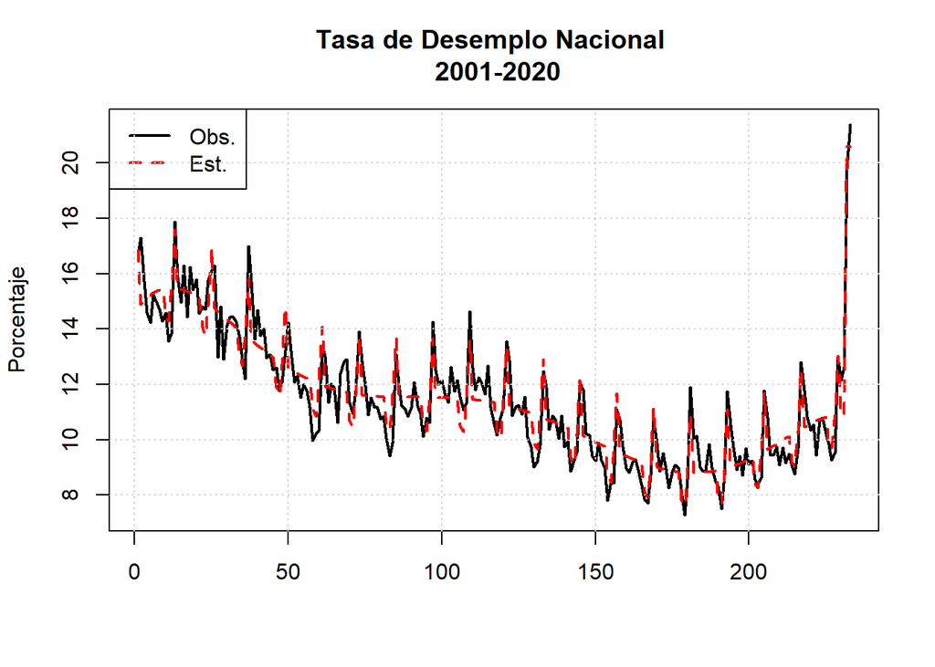

```r
tmp = cbind(td,R_pol$fitted.values)                    # variable que agrupa Observado y Estimado
matplot(tmp,type="l",
        lwd = c(2,2),
        col = c("black","red"),
        ylab='Porcentaje', xlab='')
title(main = "Tasa de Desemplo Nacional \n 2001-2020") # \n genera una segunda linea en el titulo
legend(x = "topleft", legend = c("Obs.","Est."),
       lty = c(1,2), lwd = c(2,2), col = c("black","red") )
grid()                                                 # agrega lineas secundarias
```